# All Cops are Trusted? How Context and Time Shape Immigrants’ Trust in the Police

ECSR Annual Conference 2021, 08 Oct 2021

## Motivation

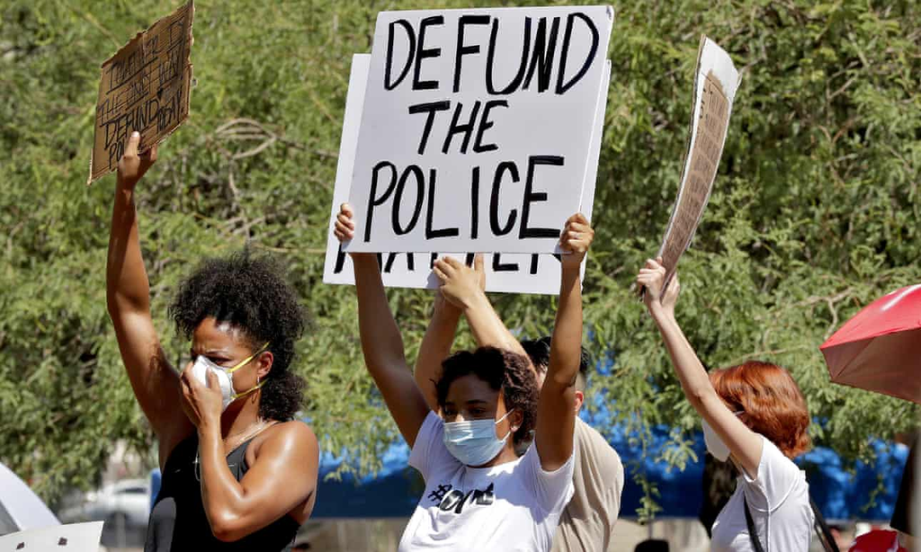

https://www.theguardian.com/us-news/2020/jun/04/defund-the-police-us-george-floyd-budgets

## Length of stay in host country

- Paradox: First generation immigrants trust police *more* than natives, but second generation migrants trusts *less* than natives (Röder & Mühlau 2012)
- But “second generation immigrants” is a notoriously noisy (heterogeneous) category
- Better: Compare within the group of first generation immigrants only
- Two mechanisms: acclimatization & accumulation of discrimination experiences

## Explaining immigrants’ decreasing trust

- Acclimatization: Reference to origin country important for recent immigrants, but migration experience fades with time
- Hypothesis: Positive effect of migrating from a country with corrupt institutions should decrease with length of stay
- Accumulation of discrimination: more time implies more “opportunity” to experience negative contact and discrimination by police
- Hypothesis: Effect of discrimination increases with length of stay

## Police size and immigrant trust

- Larger police numbers are associated with less trust (Nägel & Vera 2021)
- For immigrants, more police might also imply higher chances of negative encounters
- Hypothesis: Immigrants in countries with more police trust less
- Negative contact should be more likely the longer a migrant stayed in a country with more police
- Hypothesis: Police numbers effect increases with length of stay

## Data

- Last seven waves of European Social Survey (3-9)
- Focus on (first generation) immigrants
- Initial data include 20676 individuals nested in 150 country-years nested in 29 countries

## Country-years, part i

```
       3   4   5   6   7   8   9
  AT 125   0   0   0 185 182 253
  BE 145 145 180 248 220 244 260
  BG   0   0  16  10   0   0  16
  CH 301 379 310 298 345 372 355
  CY  33  83  57 109   0   0  70
  CZ   0  32  39  45  40  45  38
  DE 200 200 253 269 279 264 273
  DK  72  85  94  93 110   0  90
  EE 278 253   0 338 370 278 251
  ES 138 224 175 209 149 192 190
  FI  37  53  64  92  97  44  45
  FR 181 156 152 203 211 206 224
  GB   0   0 226 226 158 127   0
  GR   0   0 242   0   0   0   0
```

## Country-years, part ii

```
       3   4   5   6   7   8   9
  HR   0 101 139   0   0   0 169
  HU  24  16  35  19  22  20  15
  IE 196 279 365 354 273   0   0
  IS   0   0   0  39   0  49  39
  IT   0   0   0  52   0 136   0
  LT   0   0  72  54  58  42  51
  LV 178 251   0   0   0   0  95
  NL 151 153 125   0 148 112 147
  NO 103 104 148 101 100   0   0
  PL  13  15  14  19  10   8   8
  PT 123 129 128 109  89  91 121
  RO   4  10   0   0   0   0   0
  SE 198 200 156 211 213 167   0
  SI  80  93  87 102  90 112 130
  SK  39  40  40  25   0   0  16
```

## Data cleaning

- Removed country-years with less than 50 observations (after listwise deletion)
- Dropped 1021 individuals in 38 country-years and 7 countries from the initial data
- Covered countries in final analysis: AT BE CH CY DE DK EE ES FI FR GB GR HR IE IT LT LV NL NO PT SE SI
- Results similar to not dropping any country-years or dropping those with less than 100 observations

## Variables (individual-level)

- Outcome: *“please tell me on a score of 0-10 how much you personally trust each of the institutions I read out. 0 means you do not trust an institution at all, and 10 means you have complete trust.”* –> The police
- Variance decomposition: 0.1 is variance between countries, 0.02 is within countries over time, 0.88 is between individuals
- Treatment: Time since immigration (harmonized in 5 categories) (*length of stay (LoS)*)
- Moderator: Difference in Freedom House’s Rule of Law score between origin and destination country (*institutional improvement*)
- Moderator: *“Would you describe yourself as being a member of a group that is discriminated against in this country?”*
- Controls: education, income satisfaction, gender, age, age²

## Variables (macro-level)

- Treatment: number of police officers per 100,000 inhabitants in country per each year (Eurostat)
- Controls: GDP/capita (Eurostat), Rule of Law in destination country (theoretical range: 0 (worst) to 16 (best); Freedom House), crime rates (homicides per 100k; Eurostat)

## More police, less trust

- True: r = -0.6673778

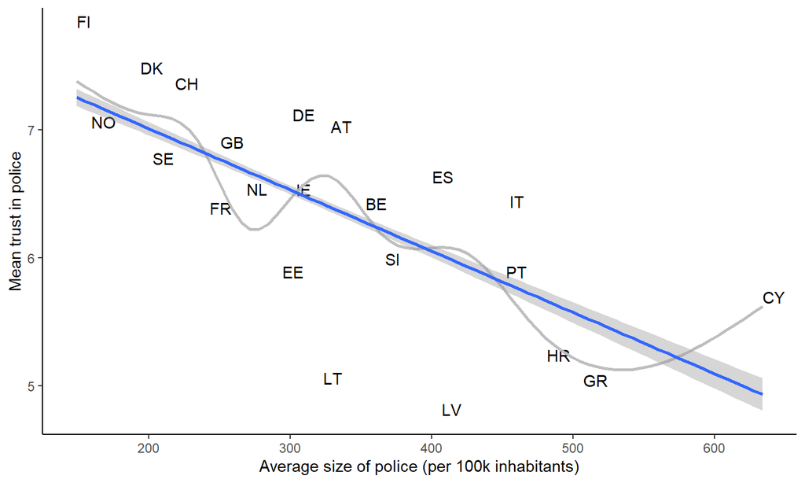

## Trend in police trust among immigrants in Europe

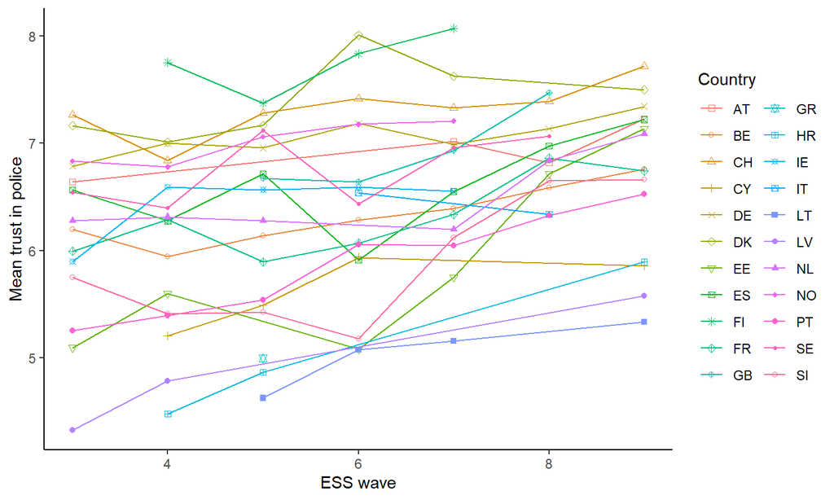

## Trends in police numbers in Europe

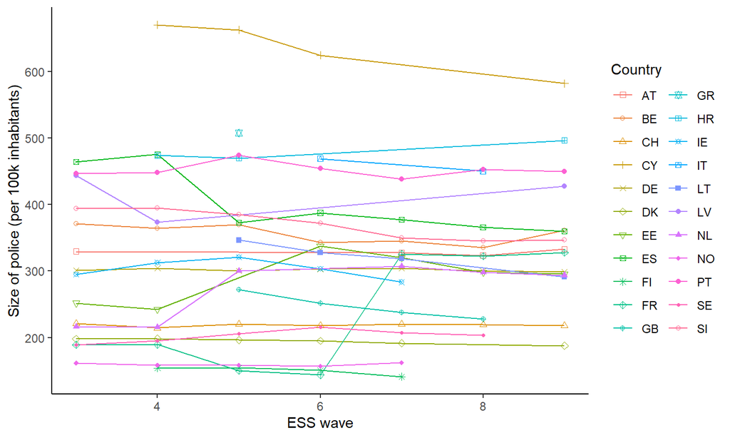

## Statistical model

- Hierarchical linear model with three levels (Schmidt-Catran & Fairbrother 2016)
- Country variables decomposed into within (WE) and between effects (BE) (Fairbrother 2014)
- WE not plagued by unobserved heterogeneity
- For cross-level interaction: Genuine within estimator (Giesselmann & Schmidt-Catran 2019), plus random slope (Heisig & Schaeffer 2019)

## Results

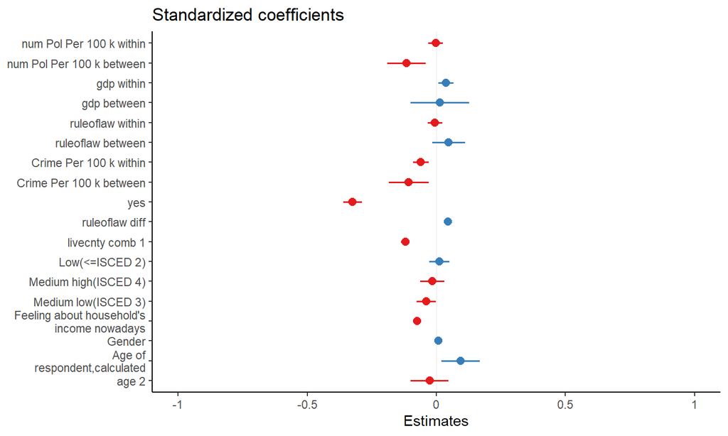

## Effect of police size conditional on LoS (WE)

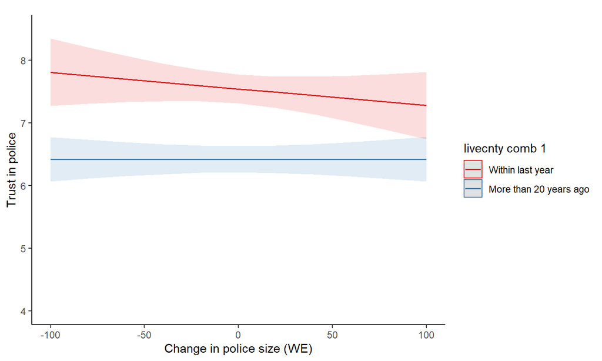

## Effect of police size conditional on LoS (BE)

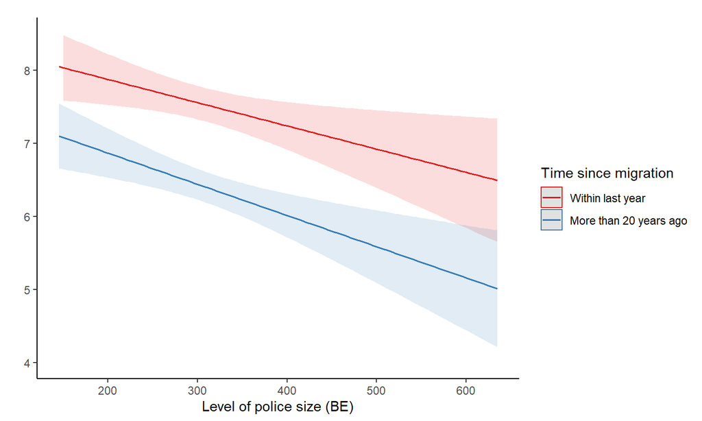

## Effect of institutional improvement conditional on LoS

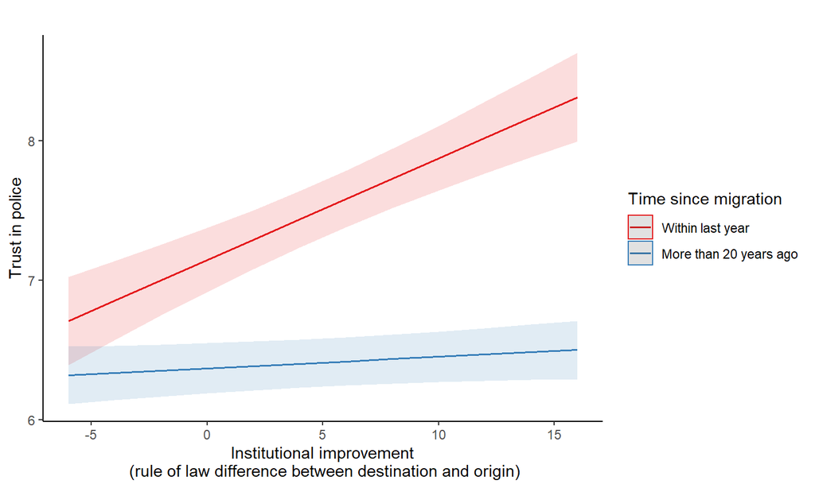

## Effect of discrimination conditional on LoS

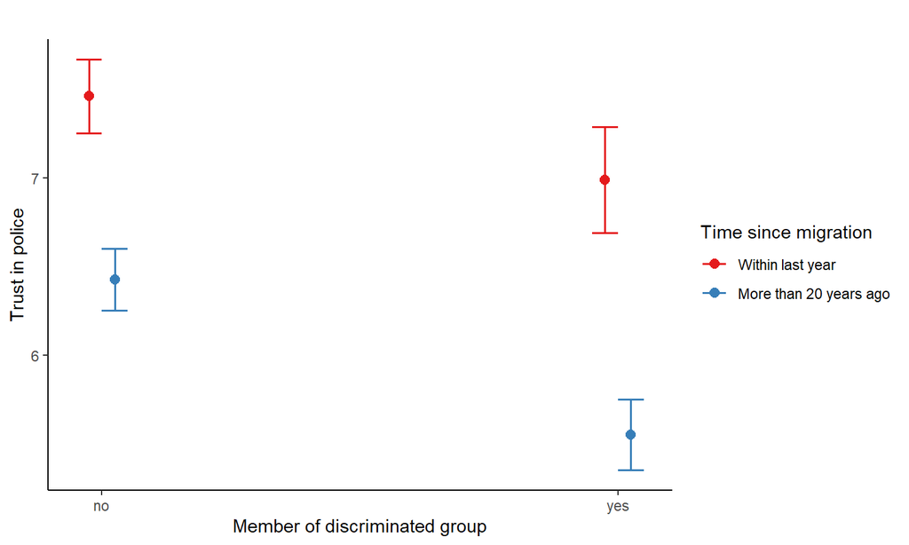

## Summary

- Individual-level hypotheses confirmed:
- Longer stay in host country is associated with less trust
- Stronger effect of institutional improvement for recent immigrants
- Discrimination effect becomes stronger over time
- Country-level hypotheses mostly not confirmed:
- Trust lower in countries with more police (BE), but more police does not lead to lower trust (WE)
- Police size effect not stronger for long-term immigrants
- Pre-print available at: https://osf.io/preprints/socarxiv/3xcpn/